# EDA 72: Outcome Groups and the Days-Absent Scale

# Analysis

## Graph Family g1: Outcome Groups and the Days-Absent Scale

This family carries both subjects of the report. The **outcome-group partition** – No Days, Chronic Days, Non-Chronic Days – is reproduced unchanged at the left of every graph below, so that each view of the numeric outcome is read against the population it comes from. The panels at right show `days_absent_total` at the exact scale and at two coarsenings.

The exact support of `days_absent_total` runs from 1 to 63 among respondents who missed any work. The chronic component runs only from 1 to 31. That difference is not a rounding artifact; it follows from chronic days being one of eight reasons summed into the total.

**Map every exact days-absent value to each proposed scale**

```r
# The coarsening rules are applied to the full days_absent support, 1 to 63.
g1_scale_mapping <- make_scale_mapping(days_absent_max)

# Labels are drawn only on the two coarsened rows; the exact row is read off the
# x axis, which stays legible where 63 in-tile labels would not.
g1_scale_labels <- g1_scale_mapping %>%
  filter(scale != "Exact reported days") %>%
  group_by(scale, bin_index, bin_label) %>%
  summarise(label_x = mean(days_absent), .groups = "drop")
```

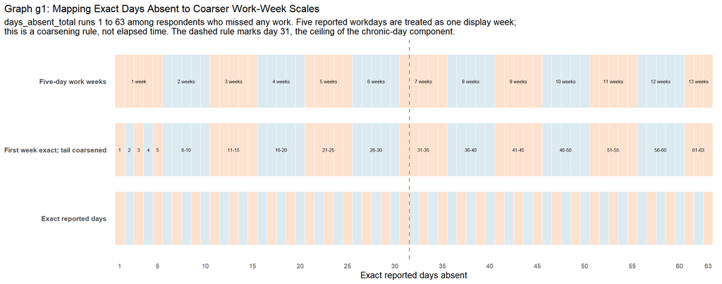

Graph g1: Every exact days-absent value from 1 to 63 mapped to the exact, five-day work-week, and first-week-exact scales. Alternating bands reveal bin boundaries; labels state the category readers would see. The dashed rule marks day 31, the ceiling of the chronic-day component.

### g11 - Days Absent at Three Scales

Graph g11 places the three-way cohort partition at left and, at right, the distribution of `days_absent_total` among all 18,837 respondents who missed at least one day – the Chronic and Non-Chronic groups combined. The three right-hand panels hold the same people at the exact, five-day work-week, and first-week-exact scales. The bluish ramp signals the whole measure.

Read the panels against each other: the five-day binning collapses the first five one-day bars, which is where most of the mass sits, into a single 15,176-respondent column. The hybrid scale is the compromise that keeps that structure visible while still taming the tail.

**Prepare the three-way cohort partition and days-absent frequencies**

```r
# Extend the EDA-71 G22 composition: the unchanged three-way respondent partition
# sits at left, while the distribution of days_absent_total among every
# respondent who missed at least one day is shown at three scales. The bluish
# ramp signals that this is the whole outcome measure, not the chronic subset.
g11_partition_summary <- ds0 %>%
  filter(!is.na(outcome_group)) %>%
  count(outcome_group, name = "n_raw") %>%
  mutate(
    pct_raw = n_raw / sum(n_raw) * 100,
    outcome_group = factor(outcome_group, levels = outcome_group_levels)
  )

g11_days_absent_exact <- ds0 %>%
  filter(days_absent_total > 0) %>%
  count(days_absent_total, name = "n_raw") %>%
  tidyr::complete(days_absent_total = 1:days_absent_max, fill = list(n_raw = 0L)) %>%
  add_day_scales("days_absent_total", days_absent_max)

stopifnot(sum(g11_days_absent_exact$n_raw) == n_any_days)

g11_basis_label <- paste0(
  "All respondents with >0 days absent (Chronic + Non-Chronic), n = ",
  scales::comma(n_any_days)
)
```

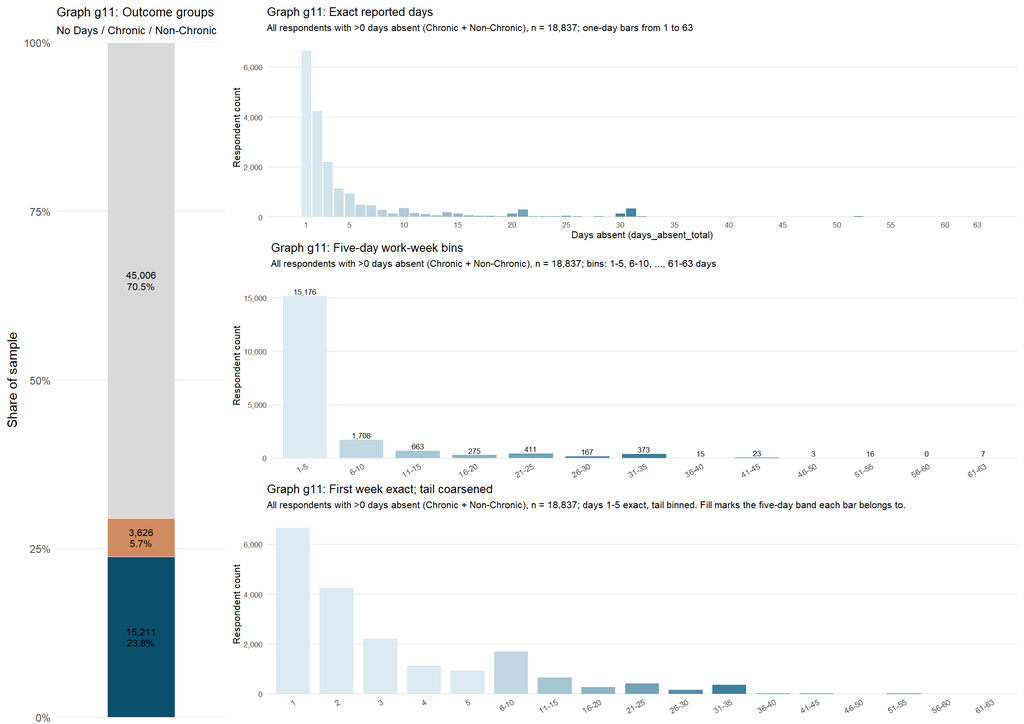

Graph g11: Left panel shows all three outcome groups (No Days n=45,006; Chronic n=3,626; Non-Chronic n=15,211). Right panels use every respondent with >0 days absent (n=18,837) and show days_absent_total at the exact, five-day, and first-week-exact scales.

#### g111 - The Chronic Component at the Same Three Scales

Graph g111 repeats the g11 construction on the chronic component alone. It is the same design, the same three scales, and the same partition panel; only the measure and the basis change. The reddish ramp signals the subset.

Two differences are worth naming. The support ends at day 31 rather than 63, and the terminal value carries visible mass – 251 respondents report exactly 31 chronic days, which is consistent with a reporting ceiling rather than a smooth tail.

**Prepare chronic-day frequencies on the same scale construction**

```r
# The same construction restricted to the chronic component. Read against g11,
# it shows that chronic days are one slice of days_absent: a shorter support
# (1 to 31) held by a smaller group.
g111_chronic_exact <- ds0 %>%
  filter(outcome_group == "Chronic Days") %>%
  count(days_absent_chronic, name = "n_raw") %>%
  tidyr::complete(days_absent_chronic = 1:chronic_days_max, fill = list(n_raw = 0L)) %>%
  add_day_scales("days_absent_chronic", chronic_days_max)

stopifnot(sum(g111_chronic_exact$n_raw) == n_chronic_days)

g111_basis_label <- paste0(
  "Chronic Days group only (>=1 chronic day), n = ", scales::comma(n_chronic_days)
)
```

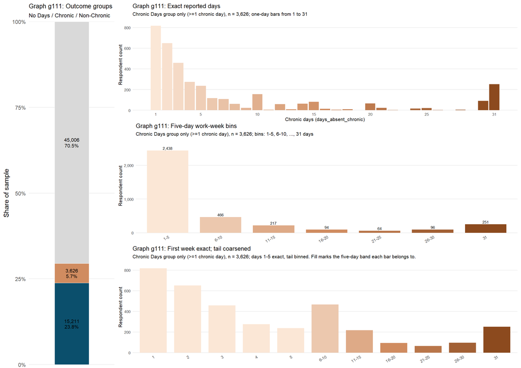

Graph g111: The g11 construction restricted to the chronic component. Right panels use the Chronic Days group only (>=1 chronic day; n=3,626) and show days_absent_chronic, support 1 to 31.

### g12 - Both Positive-Day Groups on the Same Measure

Graph g12 compares the two positive-day groups on one measure, `days_absent_total`. An earlier version of this graph used chronic days for one group and total days for the other while labelling both “missed days”; that comparison was not like-for-like and has been withdrawn. Bar colour is the group colour from the partition panel.

Within each row, the first panel preserves days 1 through 5 and the second groups the remaining tail into work-week bins 2 through 13. Row scales are free, so the two rows show shape rather than magnitude; the left panel carries the magnitude.

**Prepare hybrid days-absent frequencies for both positive-day groups**

```r
# Both positive-day groups placed on the SAME measure, days_absent_total. An
# earlier version of this graph mixed measures -- chronic days for one group,
# total days for the other -- and labelled both "missed days". Bar colour is the
# group colour carried over from the partition panel at left.
g12_partition_summary <- g11_partition_summary

hybrid_index_max <- hybrid_bin_index(days_absent_max)

g12_hybrid_distribution <- ds0 %>%
  filter(days_absent_total > 0) %>%
  transmute(
    outcome_group = factor(
      as.character(outcome_group),
      levels = c("Chronic Days", "Non-Chronic Days")
    ),
    hybrid_index = hybrid_bin_index(days_absent_total)
  ) %>%
  count(outcome_group, hybrid_index, name = "n_raw") %>%
  tidyr::complete(
    outcome_group,
    hybrid_index = seq_len(hybrid_index_max),
    fill = list(n_raw = 0L)
  ) %>%
  hybrid_panel_frame()

stopifnot(sum(g12_hybrid_distribution$n_raw) == n_any_days)
```

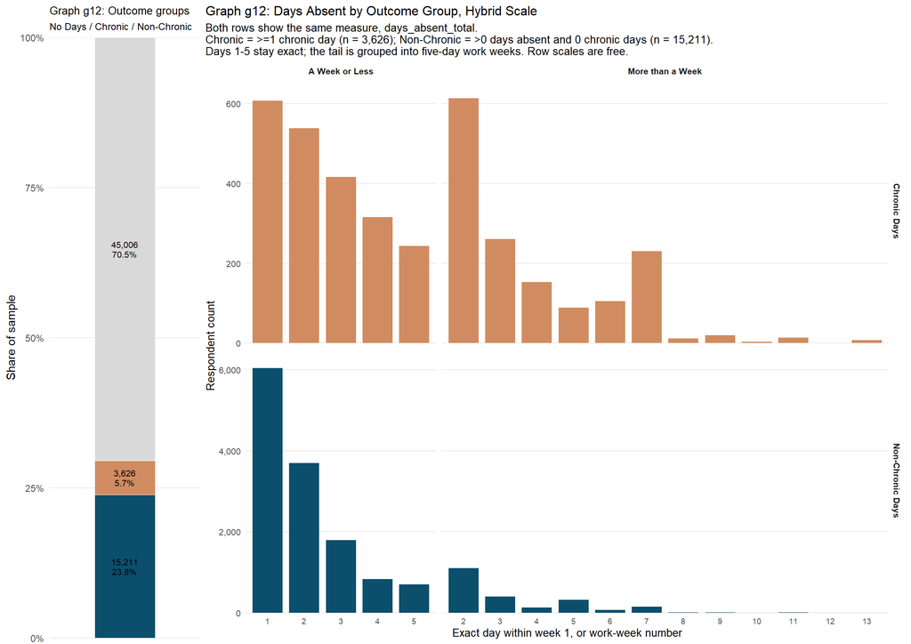

Graph g12: Left panel shows the full three-group partition. Right panels show days_absent_total for Chronic (>=1 chronic day; n=3,626) and Non-Chronic (>0 days absent and 0 chronic days; n=15,211). Days 1-5 remain exact; values above day 5 are grouped into work-week bins 2 through 13. Row scales are free.

#### g121 - Two Measures on the Same Respondents

Graph g121 makes the subset relation visible on a single set of people. The 3,626 Chronic Days respondents are counted twice: once by all days absent, once by the chronic component of those same days. The chronic row cannot extend past work-week 7, because 31 is the component’s ceiling, while the total row reaches work-week 13.

This is the graph to consult whenever a reader is tempted to treat “chronic days” and “days absent” as interchangeable labels for the same quantity.

**Prepare both day measures for the Chronic Days group**

```r
# The subset relation on one set of people. Within the Chronic Days group, the
# same respondents are counted twice: once by all days absent, once by the
# chronic component of those days. The chronic bars can never sit to the right
# of the total bars, because chronic days are drawn from the same total.
g121_measure_levels <- c("All days absent", "Chronic days only")
g121_measure_colours <- c(
  "All days absent" = unname(outcome_group_colours[["Non-Chronic Days"]]),
  "Chronic days only" = unname(outcome_group_colours[["Chronic Days"]])
)

g121_measure_distribution <- ds0 %>%
  filter(outcome_group == "Chronic Days") %>%
  select(days_absent_total, days_absent_chronic) %>%
  tidyr::pivot_longer(
    cols = everything(),
    names_to = "measure_column",
    values_to = "day_value"
  ) %>%
  mutate(
    measure = factor(
      if_else(
        measure_column == "days_absent_total",
        g121_measure_levels[1],
        g121_measure_levels[2]
      ),
      levels = g121_measure_levels
    ),
    hybrid_index = hybrid_bin_index(day_value)
  ) %>%
  count(measure, hybrid_index, name = "n_raw") %>%
  tidyr::complete(
    measure,
    hybrid_index = seq_len(hybrid_index_max),
    fill = list(n_raw = 0L)
  ) %>%
  hybrid_panel_frame()

stopifnot(sum(g121_measure_distribution$n_raw) == 2L * n_chronic_days)

g121_measure_means <- ds0 %>%
  filter(outcome_group == "Chronic Days") %>%
  summarise(
    mean_total = weighted_mean(days_absent_total, weight_value),
    mean_chronic = weighted_mean(days_absent_chronic, weight_value)
  )
```

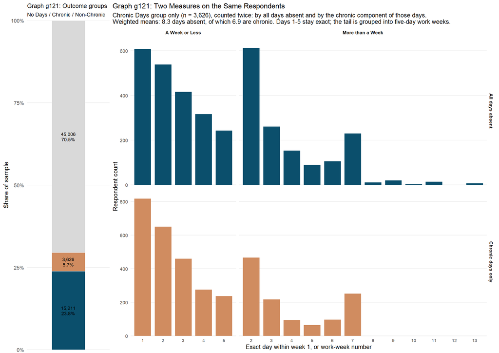

Graph g121: Chronic Days group only (n=3,626), counted twice. Upper row is days_absent_total; lower row is days_absent_chronic. Days 1-5 remain exact; the tail is grouped into five-day work weeks.

#### g122 - Both Positive-Day Groups on the Raw Day Scale

Graph g122 repeats the g12 comparison with the coarsening removed: one bar per reported day across the full 1 to 63 support. The top row holds the respondents who missed at least one day because of a chronic condition; the bottom row holds those who missed at least one day and none of them chronic. Both rows carry the same measure, `days_absent_total`, and are completed over the same support, so the rows differ only in who is counted.

The raw scale shows what the work-week bins absorb - the spikes at round numbers (5, 10, 14, 15, 20, 30) that reporting habits produce, and the thin scatter across the upper tail. Read g12 for shape at a glance and g122 for the reporting texture underneath it.

**Prepare exact one-day frequencies for both positive-day groups**

```r
# The g12 comparison held at the raw scale: one bar per reported day, no
# coarsening. Top row is the Chronic Days group (>=1 day missed because of a
# chronic condition); bottom row is the Non-Chronic Days group (>=1 day missed
# and none of them chronic). Both rows carry the SAME measure, days_absent_total,
# and are completed over its full 1-63 support so the two rows share one x axis.
g122_group_exact <- ds0 %>%
  filter(days_absent_total > 0) %>%
  transmute(
    outcome_group = factor(
      as.character(outcome_group),
      levels = c("Chronic Days", "Non-Chronic Days")
    ),
    day_value = as.integer(days_absent_total)
  ) %>%
  count(outcome_group, day_value, name = "n_raw") %>%
  tidyr::complete(
    outcome_group,
    day_value = seq_len(days_absent_max),
    fill = list(n_raw = 0L)
  )

stopifnot(sum(g122_group_exact$n_raw) == n_any_days)

g122_group_means <- ds0 %>%
  filter(days_absent_total > 0) %>%
  group_by(outcome_group) %>%
  summarise(
    mean_total = weighted_mean(days_absent_total, weight_value),
    .groups = "drop"
  )
```

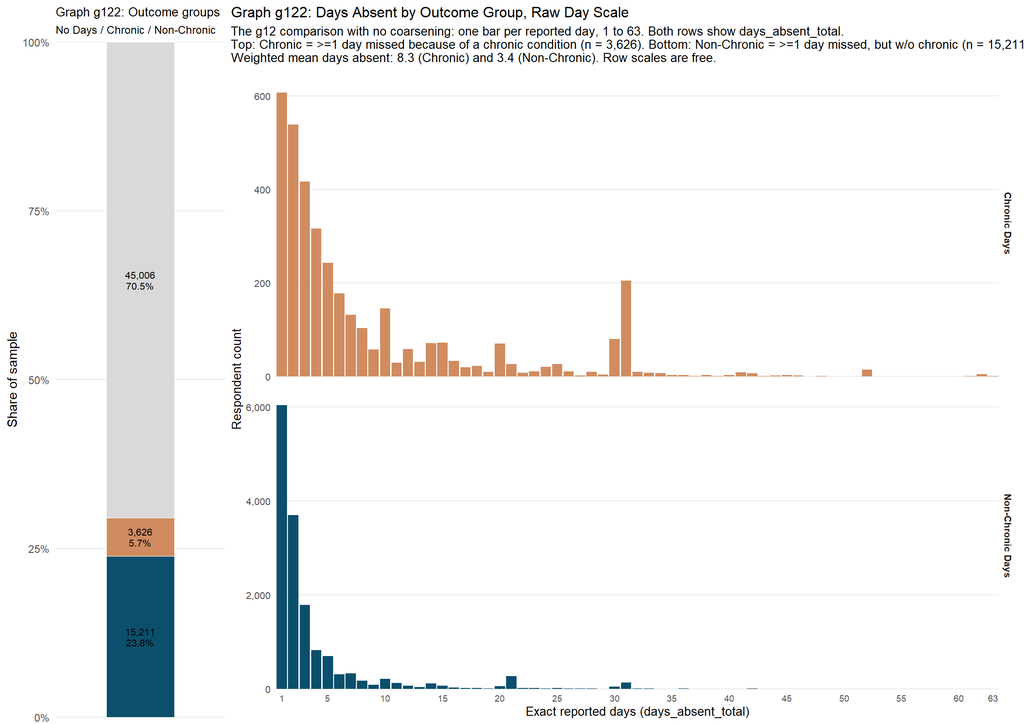

Graph g122: Left panel shows the full three-group partition. Right panels show days_absent_total at the exact one-day scale for Chronic (>=1 day missed because of a chronic condition; n=3,626) and Non-Chronic (>=1 day missed, none of them chronic; n=15,211). Both rows span days 1 to 63. Row scales are free.

## Graph Family g2: Evaluating a Variable Set Against the Outcome Groups

This family is an **illustration of a method**, not a set of substantive findings. Family g1 established the groups and the scale; this family shows one way a set of candidate variables can be examined against those groups. The predisposing domain serves as the worked example because it is the first block of the project’s candidate registry. The same displays would serve any other domain unchanged.

Graphs g2, g20, g21, g211, and g212 are composition contrasts and use the pooled survey weight. Graphs g22 through g24 condition on the 3,626 Chronic Days respondents and report the chronic component, `days_absent_chronic`, which is labelled as such.

**Prepare weighted composition contrasts and chronic-day intensity**

```r
g2_composition_all <- predictor_long %>%
  filter(outcome_group %in% outcome_group_levels, !is.na(level)) %>%
  group_by(outcome_group, variable, variable_label, level) %>%
  summarise(
    n_raw = n(),
    weight_sum = sum(weight_value, na.rm = TRUE),
    .groups = "drop_last"
  ) %>%
  mutate(
    pct_raw = n_raw / sum(n_raw) * 100,
    pct_weighted = weight_sum / sum(weight_sum) * 100
  ) %>%
  ungroup() %>%
  mutate(outcome_group = factor(outcome_group, levels = outcome_group_levels)) %>%
  add_facet_level()

g2_composition <- g2_composition_all %>%
  filter(outcome_group %in% comparison_group_levels) %>%
  mutate(outcome_group = factor(outcome_group, levels = comparison_group_levels))

g2_difference <- g2_composition %>%
  select(variable, variable_label, level, outcome_group, pct_weighted, facet_level) %>%
  tidyr::pivot_wider(names_from = outcome_group, values_from = pct_weighted) %>%
  mutate(difference_pp = `Chronic Days` - `No Days`)

g2_pairwise_differences <- g2_composition_all %>%
  select(variable, variable_label, level, outcome_group, pct_weighted, facet_level) %>%
  tidyr::pivot_wider(names_from = outcome_group, values_from = pct_weighted) %>%
  mutate(
    non_chronic_minus_no_days = `Non-Chronic Days` - `No Days`,
    chronic_minus_non_chronic = `Chronic Days` - `Non-Chronic Days`
  )

g2_intensity <- predictor_long %>%
  filter(outcome_group == "Chronic Days", !is.na(level)) %>%
  group_by(variable, variable_label, level) %>%
  summarise(
    n_raw = n(),
    mean_chronic_days = weighted_mean(days_absent_chronic, weight_value),
    .groups = "drop"
  ) %>%
  add_facet_level()

g2_exact_distribution <- predictor_long %>%
  filter(outcome_group == "Chronic Days", !is.na(level)) %>%
  group_by(variable, variable_label, level, days_absent_chronic) %>%
  summarise(weight_sum = sum(weight_value, na.rm = TRUE), .groups = "drop_last") %>%
  tidyr::complete(days_absent_chronic = 1:31, fill = list(weight_sum = 0)) %>%
  mutate(pct_within_level = weight_sum / sum(weight_sum) * 100) %>%
  ungroup() %>%
  add_facet_level()
```

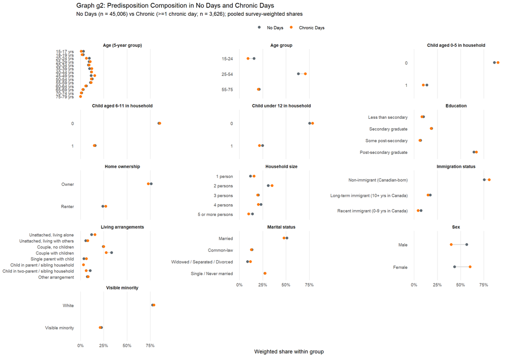

Graph g2: Pooled survey-weighted composition of No Days (n=45,006) and Chronic respondents (>=1 chronic day; n=3,626) within each predisposing variable.

### g20 - Composition Across All Three Groups

Graph g20 adds the Non-Chronic Days group to the same canvas. Its grey, brown, and blue group colours match EDA-71 graph g2 so the outcome partition remains visually consistent across reports.

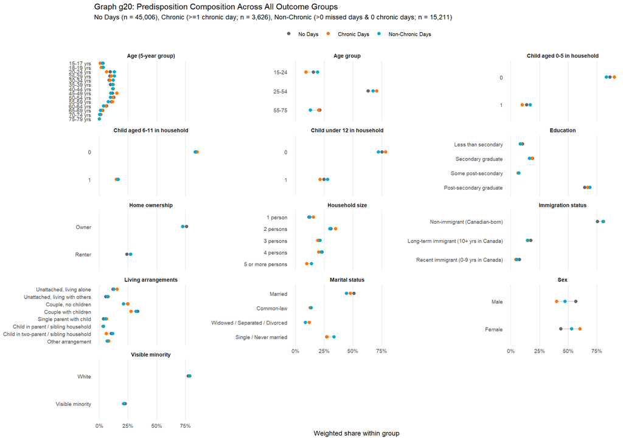

Graph g20: Pooled survey-weighted composition across No Days (n=45,006), Chronic (>=1 chronic day; n=3,626), and Non-Chronic (>0 missed days and 0 chronic days; n=15,211). Colours reproduce the EDA-71 graph g2 outcome palette.

### g21 - Composition Difference

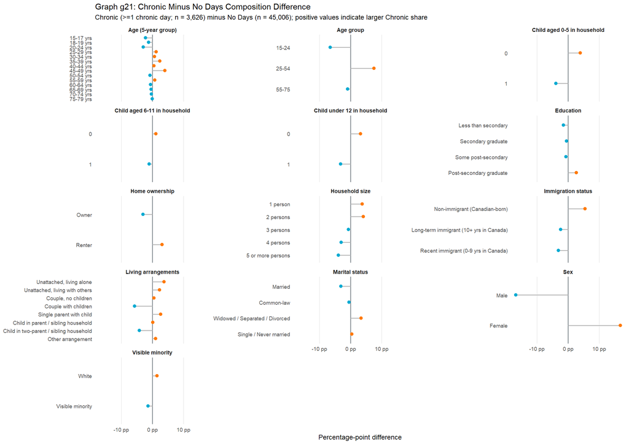

Graph g21: Weighted percentage-point difference calculated as Chronic (>=1 chronic day; n=3,626) minus No Days (n=45,006) for each predictor level.

#### g211 - Non-Chronic Minus No Days

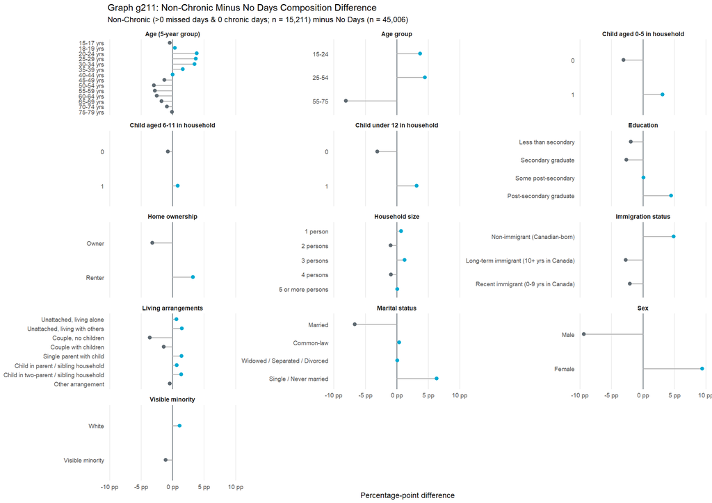

Graph g211: Weighted percentage-point difference calculated as Non-Chronic (>0 missed days and 0 chronic days; n=15,211) minus No Days (n=45,006) for each predictor level.

#### g212 - Chronic Minus Non-Chronic Days

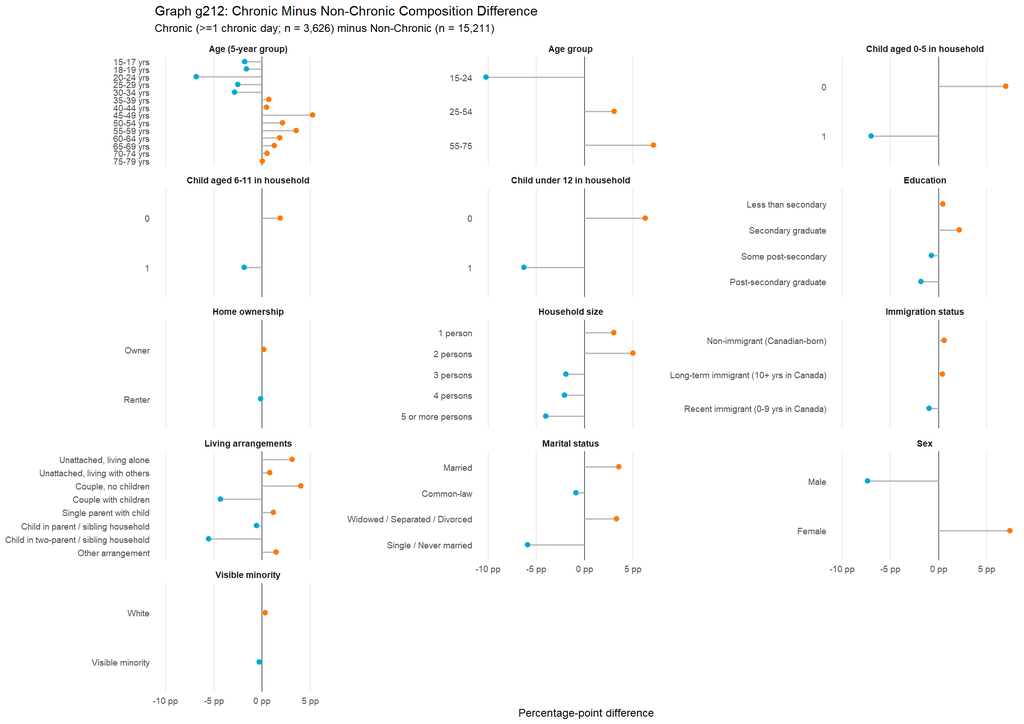

Graph g212: Weighted percentage-point difference calculated as Chronic (>=1 chronic day; n=3,626) minus Non-Chronic (>0 missed days and 0 chronic days; n=15,211) for each predictor level.

### g22 - Chronic-Day Intensity

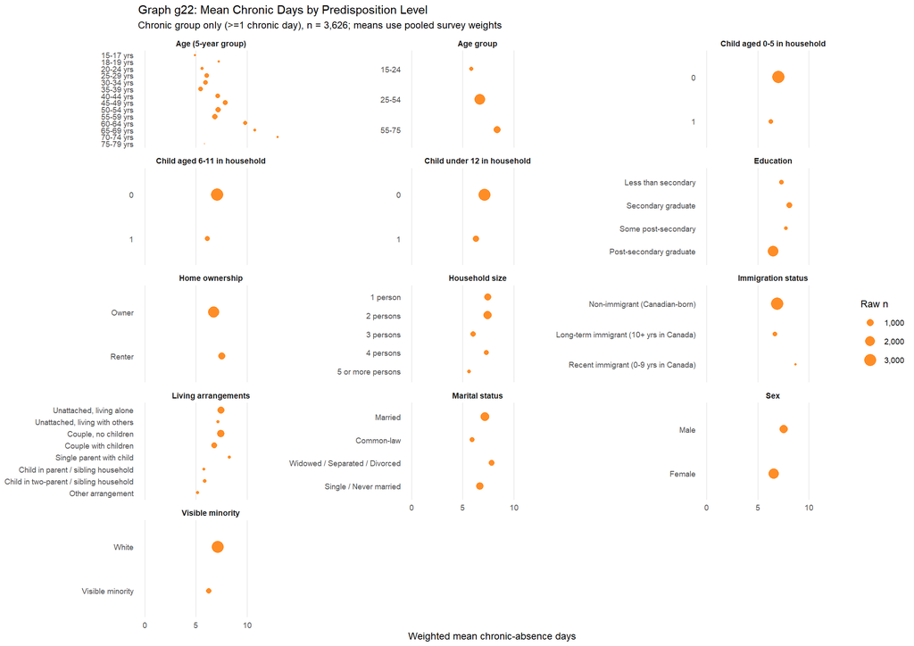

Graph g22: Pooled survey-weighted mean chronic-absence days within each predictor level among Chronic respondents only (>=1 chronic day; n=3,626).

### g23 - Exact Positive-Day Distribution

Graph g23 continues the thought of EDA-71’s `g23_chronic_vs_other_only_split_distribution`: it preserves every exact positive chronic-day value, but replaces the other-only comparison with predisposing-variable levels. Each row has its own 100% conditional denominator.

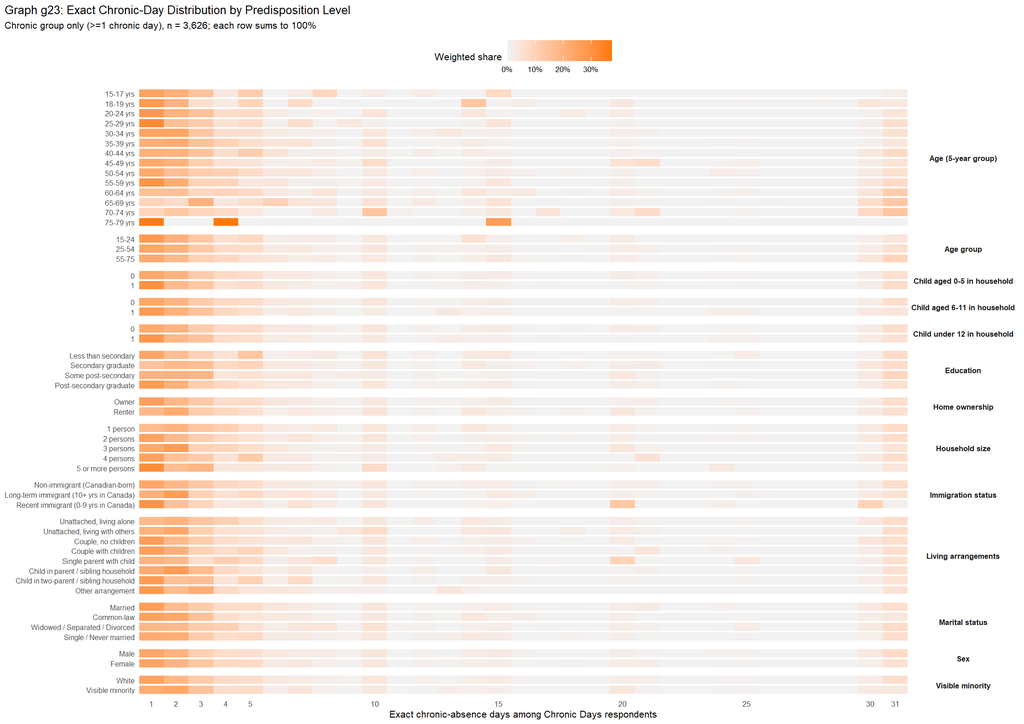

Graph g23: Exact chronic-day values among Chronic respondents only (>=1 chronic day; n=3,626), stratified by predisposing-variable level. Each row sums to 100%.

### g24 - Exact Distribution With Composition Tiles

Graph g24 retains g23’s exact-day matrix and adds two composition columns. The respondent-count column uses raw subgroup counts converted to shares, while the weighted-share column uses the pooled survey weight. Each column sums to 100% within a predictor, allowing levels such as age 15-24 to be read in context.

**Prepare raw respondent-count shares and weighted shares by predictor level**

```r
g24_composition_tiles <- g2_composition_all %>%
  filter(outcome_group == "Chronic Days") %>%
  select(variable, variable_label, facet_level, pct_raw, pct_weighted) %>%
  tidyr::pivot_longer(
    cols = c(pct_raw, pct_weighted),
    names_to = "measure",
    values_to = "share"
  ) %>%
  mutate(
    measure = factor(
      measure,
      levels = c("pct_raw", "pct_weighted"),
      labels = c("Respondent\nshare", "Weighted\nshare")
    )
  )

stopifnot(
  all(
    abs(
      g24_composition_tiles %>%
        group_by(variable, measure) %>%
        summarise(total = sum(share), .groups = "drop") %>%
        pull(total) - 100
    ) < 1e-8
  )
)
```

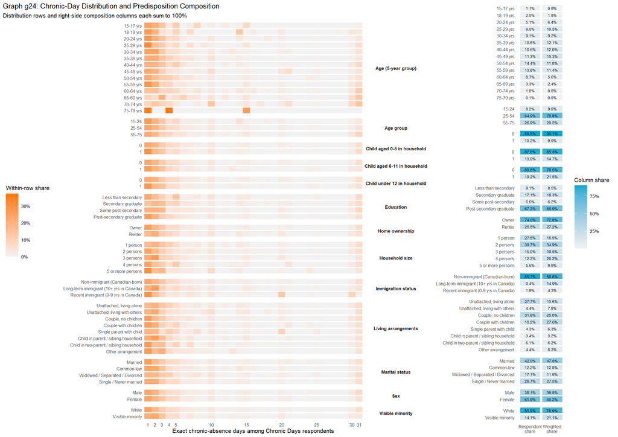

Graph g24: Left matrix shows exact chronic-day distributions; right columns show respondent-count share and weighted share. Rows are aligned so each category appears on the same row on both sides.

## Graph Family g3: Reference Profile of the No Days Group

This family is reference material, not argument. It answers “what does the largest outcome group look like” rather than “how do the groups differ”, so it sits after the two substantive families rather than before them.

It was previously numbered g0 and placed first, which gave a lookup profile the position of a lead finding. The IDs `g0` and `g01` are retired and are not reused.

**Prepare weighted predisposing-variable distributions for No Days**

```r
g3_data <- predictor_long %>%
  filter(outcome_group == "No Days", !is.na(level)) %>%
  group_by(variable, variable_label, level) %>%
  summarise(
    n_raw = n(),
    weight_sum = sum(weight_value, na.rm = TRUE),
    .groups = "drop_last"
  ) %>%
  mutate(
    pct_weighted = weight_sum / sum(weight_sum) * 100,
    label = sprintf("%.1f%%", pct_weighted)
  ) %>%
  ungroup() %>%
  add_facet_level()
```

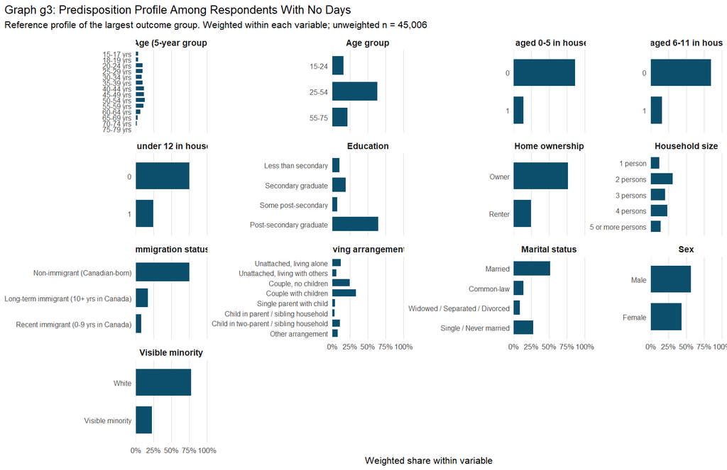

Graph g3: Weighted composition of the non-student predisposing variables among 45,006 respondents who reported No Days. Percentages sum to 100% within each variable.

### g31 - A4 Landscape Design

Graph g31 tests the same content at A4 landscape dimensions. Three facet columns, larger labels, and direct percentages trade browser compactness for print legibility.

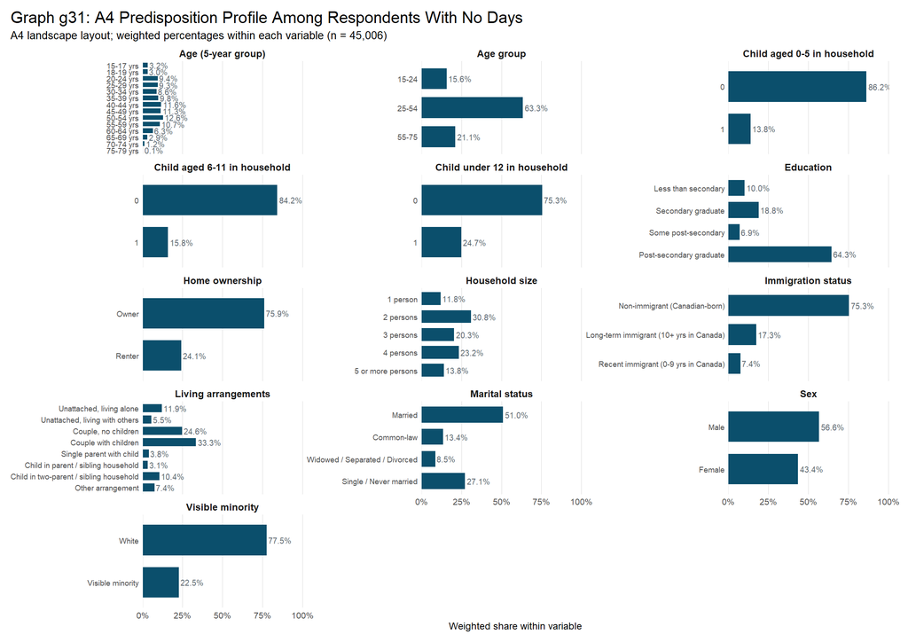

Graph g31: A4-landscape version of the No Days reference profile. Direct labels and a three-column facet layout are designed to remain legible in the browser and on an A4 landscape page.

# Appendix

Student status is excluded because the source field is suppressed and all-missing in the PUMF. The three outcome groups are exhaustive and mutually exclusive; the g2 family shows their complete composition comparison matrix.

Retired artifact IDs: `g0` and `g01` became `g3` and `g31` when the reference profile moved from first position to last. Per the project’s artifact rules the retired IDs are not reused.